# 2020 Election Analysis using Twitter

Demonstrate how to access Twitter data using rtweet package.  
Follow instructions for each section and include text annotation/ interpretation of results!  
What can be concluded based on the data investigation?

### Libraries

Common libraries

```r
# twitter library
library(rtweet)

# plotting and pipes - tidyverse
library(ggplot2)
library(dplyr, warn.conflicts = FALSE)
options(dplyr.summarise.inform = FALSE) # Suppress summarise info

# text mining library
suppressPackageStartupMessages(library(tidyverse)) # suppress startup message

# date/time libaray
library(lubridate, warn.conflicts = FALSE)
```

## Authenticate

Use create_token initially, but once the token is created, only need to use get_token() in subsequent sessions to load the token.

```r
# getting the token needs to be only done once. Once done, set tokenOk to TRUE
if (tokenOk==FALSE) {
  ## authenticate via web browser
  token <- create_token(
    app = "gguSentiment",
    consumer_key = api_key,
    consumer_secret = api_secret_key,
    access_token = access_token,
    access_secret = access_token_secret)
}

## check to see if the token is loaded
get_token()
```

```
## <Token>
## <oauth_endpoint>
##  request:   https://api.twitter.com/oauth/request_token
##  authorize: https://api.twitter.com/oauth/authenticate
##  access:    https://api.twitter.com/oauth/access_token
## <oauth_app> gguSentiment
##   key:    oGR0V4nvOX6GFTsl2Tme1PakD
##   secret: <hidden>
## <credentials> oauth_token, oauth_token_secret
## ---
```

## Retrieve most recent 3200 timelines of Trump and Biden

- use: ‘JoeBiden’ and ‘realDonaldTrump’
- don’t exclude anything
- save to csv file, so you don’t have to call the api subsequently, in case of long delays
- read the csv file into a dataframe and use that df for subsequent analysis.
  - You will notice using the View (df) function that the the object structure of the original dataframe after the AP call is different from the one you read in. The original has embedded list objects, whereas the one read in is flattend. Also the date/time fields such as ‘create_at’ is char rather than Twitter’s POSIX time format. Use lubridate datetime functions (eg: as_datetime) to convert.

## Show the column names

```r
names(timelinesdf)
```

```
##  [1] "user_id"                 "status_id"
##  [3] "created_at"              "screen_name"
##  [5] "text"                    "source"
##  [7] "display_text_width"      "reply_to_status_id"
##  [9] "reply_to_user_id"        "reply_to_screen_name"
## [11] "is_quote"                "is_retweet"
## [13] "favorite_count"          "retweet_count"
## [15] "quote_count"             "reply_count"
## [17] "hashtags"                "symbols"
## [19] "urls_url"                "urls_t.co"
## [21] "urls_expanded_url"       "media_url"
## [23] "media_t.co"              "media_expanded_url"
## [25] "media_type"              "ext_media_url"
## [27] "ext_media_t.co"          "ext_media_expanded_url"
## [29] "ext_media_type"          "mentions_user_id"
```

[output cut: 30 more lines]

## Create a table of counts of observations for each timeline

What does this tell you?

```
##
##        JoeBiden realDonaldTrump
##            3200            3182
```

## Show the top and bottom (select by fields shown) and show a summary of ‘created_at’

What is the start date/end date in the time-lines?

```
## # A tibble: 6 x 3
##   created_at          screen_name text
##   <dttm>              <chr>       <chr>
## 1 2020-10-09 02:35:00 JoeBiden    "When Governor Whitmer worked to protect her …
## 2 2020-10-09 01:15:00 JoeBiden    "Jill and I are keeping the Gulf Coast in our…
## 3 2020-10-09 00:45:00 JoeBiden    "Time and time again, President Trump has ref…
## 4 2020-10-09 00:15:00 JoeBiden    ".@CP3 and @StephenCurry30 know exactly what …
## 5 2020-10-09 00:01:00 JoeBiden    "After last night, I just had to write a note…
## 6 2020-10-08 23:25:00 JoeBiden    ".@KamalaHarris is right: If you have a pre-e…
```

```
## # A tibble: 6 x 3
##   created_at          screen_name    text
##   <dttm>              <chr>          <chr>
## 1 2020-07-15 01:43:52 realDonaldTru… "Wow, just called! @TTuberville - Tommy Tu…
## 2 2020-07-15 01:08:00 realDonaldTru… "Fantastic!! Thank you so much for your su…
## 3 2020-07-15 00:10:38 realDonaldTru… "Joe Biden claims to be prioritizing ‘safe…
## 4 2020-07-14 23:05:33 realDonaldTru… "President @realDonaldTrump: Joe Biden nev…
## 5 2020-07-14 23:05:30 realDonaldTru… "President @realDonaldTrump on Joe Biden's…
## 6 2020-07-14 23:05:24 realDonaldTru… "President @realDonaldTrump: “Make no mist…
```

```
##                  Min.               1st Qu.                Median
## "2019-10-23 20:32:00" "2020-04-24 21:20:47" "2020-08-10 17:18:19"
##                  Mean               3rd Qu.                  Max.
## "2020-06-29 02:14:06" "2020-09-09 03:18:04" "2020-10-09 03:10:51"
```

## Create a dataframe that filters on just Biden as follows:

- for timelines past 2020-02-01
- sorted by favorite_count

Show the top 10 observations (by fields shown) and the count/size

```
## # A tibble: 10 x 4
##    created_at          favorite_count retweet_count text
##    <dttm>                       <int>         <int> <chr>
##  1 2020-09-30 01:49:00        1896817        319389 Donald Trump is the worst p…
##  2 2020-04-24 18:25:00        1640840        327774 I can’t believe I have to s…
##  3 2020-10-03 18:32:00        1168589        118662 One month until Election Da…
##  4 2020-10-08 02:47:01        1058420         93124 .@KamalaHarris, you made us…
##  5 2020-10-02 12:45:10         967086         68004 Jill and I send our thought…
##  6 2020-10-02 16:22:43         914098        135734 I’m happy to report that Ji…
##  7 2020-10-08 02:33:09         887870        214336 Pitch in $5 to help this ca…
##  8 2020-09-20 01:29:00         867016        234361 I’m Joe Biden and I approve…
##  9 2020-10-02 23:46:00         843615         75036 I’m running as a Democrat, …
## 10 2020-08-11 20:17:32         836687        168305 I have the great honor to a…
```

```
## # A tibble: 1 x 1
##       n
##   <int>
## 1  2452
```

## Show and Plot retweets, replies, and original tweets aggregated over months for Biden

- use mutate to add new columns:
  - mon = floor_date(created_at, “month”)
  - original = is_retweet==FALSE & is_quote==FALSE & is.na(reply_to_status_id)
- summarize retweet_count, replies_count and orig_count (eg: sum of original)
- show the summary of this transformed data frame
- plot
  - log scale y axis, eg: scale_y_continuous(trans=‘log10’

To manually create a legned, see this example by andresrcs  
https://community.rstudio.com/t/adding-manual-legend-to-ggplot2/41651/2

```
## # A tibble: 9 x 4
##   mon                 retweets_count replies_count orig_count
##   <dttm>                       <int>         <int>      <int>
## 1 2020-02-01 00:00:00         537106             0        239
## 2 2020-03-01 00:00:00        2134142             0        240
## 3 2020-04-01 00:00:00        2451711             0        196
## 4 2020-05-01 00:00:00        2848220             0        200
## 5 2020-06-01 00:00:00        3231296             0        183
## 6 2020-07-01 00:00:00        3218044             0        203
## 7 2020-08-01 00:00:00        5148710             0        302
## 8 2020-09-01 00:00:00        5290925             0        252
## 9 2020-10-01 00:00:00        3211602             0        109
```

```
##       mon             retweets_count    replies_count   orig_count
##  Min.   :2020-02-01   Min.   : 537106   Min.   :0     Min.   :109.0
##  1st Qu.:2020-04-01   1st Qu.:2451711   1st Qu.:0     1st Qu.:196.0
##  Median :2020-06-01   Median :3211602   Median :0     Median :203.0
##  Mean   :2020-06-01   Mean   :3119084   Mean   :0     Mean   :213.8
##  3rd Qu.:2020-08-01   3rd Qu.:3231296   3rd Qu.:0     3rd Qu.:240.0
##  Max.   :2020-10-01   Max.   :5290925   Max.   :0     Max.   :302.0
```

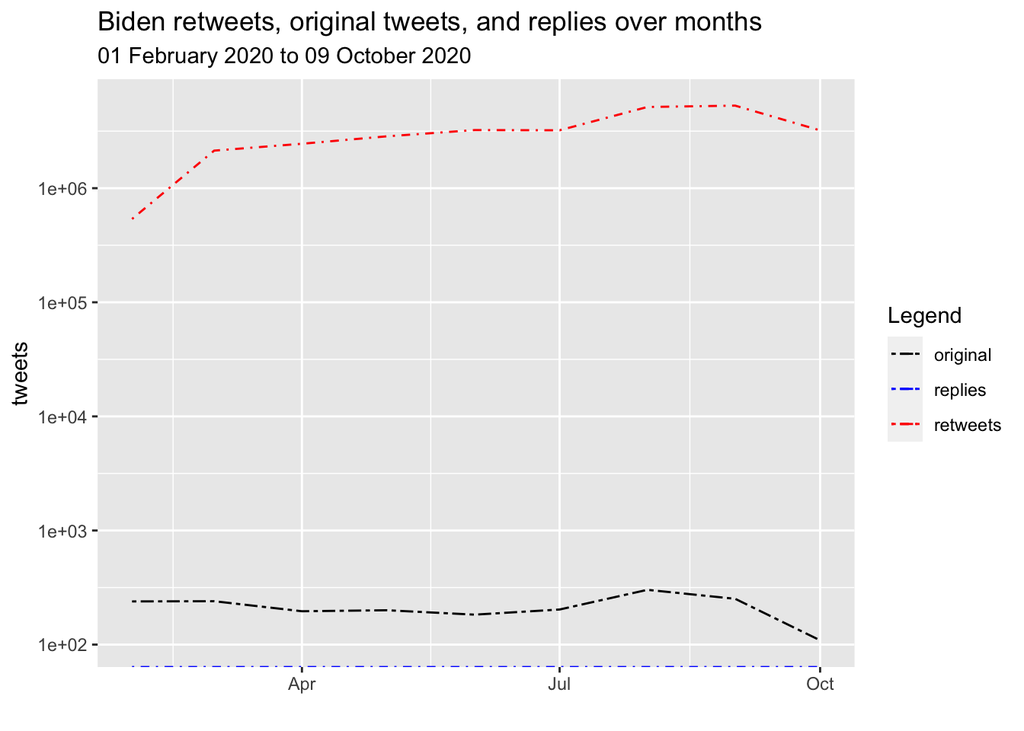

## Filter on on just Trump as follows:

- for timelines past 2020-02-01,
- sorted by favorite_count

Show the top 10 observations (by fields shown) and the count/size

```
## # A tibble: 10 x 4
##    created_at          favorite_count retweet_count text
##    <dttm>                       <int>         <int> <chr>
##  1 2020-10-02 04:54:06        1885781        415710 Tonight, @FLOTUS and I test…
##  2 2020-10-03 03:31:34        1225016        140686 Going welI, I think! Thank …
##  3 2020-10-02 22:31:56         764494        131948 https://t.co/B4H105KVSs
##  4 2020-10-03 22:51:58         719136        146777 https://t.co/gvIPuYtTZG
##  5 2020-10-03 17:19:38         653406        100891 Doctors, Nurses and ALL at …
##  6 2020-10-03 17:46:48         651766         93944 OUR GREAT USA WANTS &amp; N…
##  7 2020-10-06 14:41:06         611450         73796 FEELING GREAT!
##  8 2020-10-08 02:57:08         606513         87395 Mike Pence WON BIG!
##  9 2020-10-04 19:51:14         601459         91394 I really appreciate all of …
## 10 2020-10-05 18:37:21         597195        131384 I will be leaving the great…
```

```
## # A tibble: 1 x 1
##       n
##   <int>
## 1  3182
```

## Show and Plot retweets, replies, and original tweets aggregated over months for Trump

```
## # A tibble: 4 x 4
##   mon                 retweets_count replies_count orig_count
##   <dttm>                       <int>         <int>      <int>
## 1 2020-07-01 00:00:00        7509884             0        117
## 2 2020-08-01 00:00:00       18717192             0        427
## 3 2020-09-01 00:00:00       21333793             0        516
## 4 2020-10-01 00:00:00        8405978             0        114
```

```
##       mon                      retweets_count     replies_count   orig_count
##  Min.   :2020-07-01 00:00:00   Min.   : 7509884   Min.   :0     Min.   :114.0
##  1st Qu.:2020-07-24 06:00:00   1st Qu.: 8181954   1st Qu.:0     1st Qu.:116.2
##  Median :2020-08-16 12:00:00   Median :13561585   Median :0     Median :272.0
##  Mean   :2020-08-16 06:00:00   Mean   :13991712   Mean   :0     Mean   :293.5
##  3rd Qu.:2020-09-08 12:00:00   3rd Qu.:19371342   3rd Qu.:0     3rd Qu.:449.2
##  Max.   :2020-10-01 00:00:00   Max.   :21333793   Max.   :0     Max.   :516.0
```

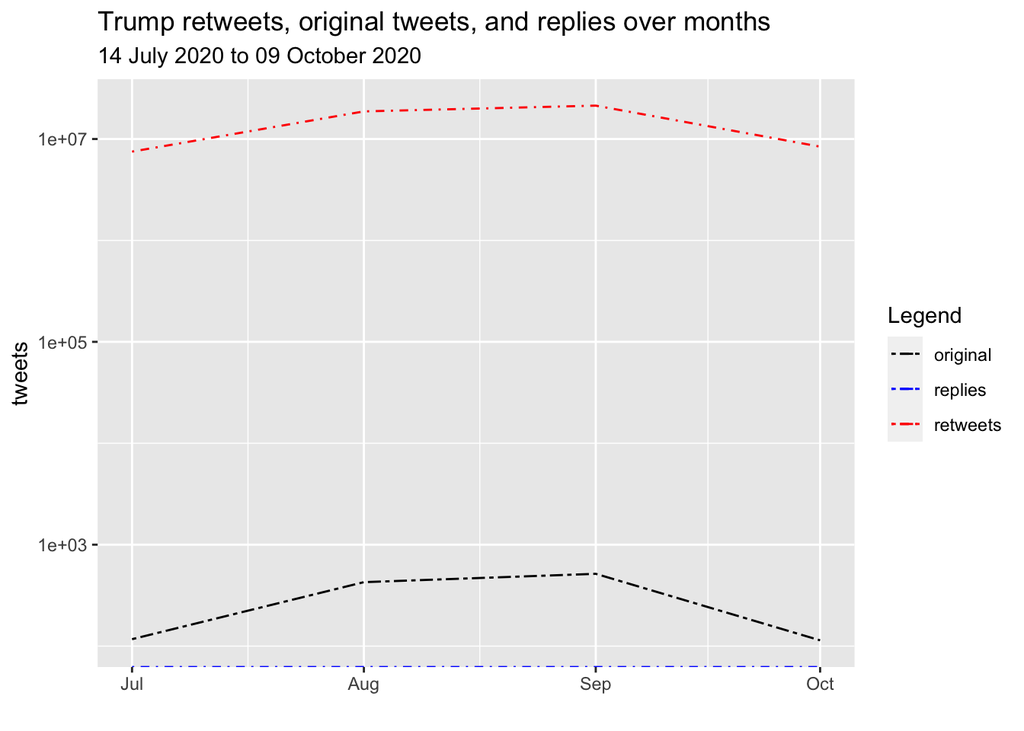

## Plot the frequency of tweets for each user

**by days**

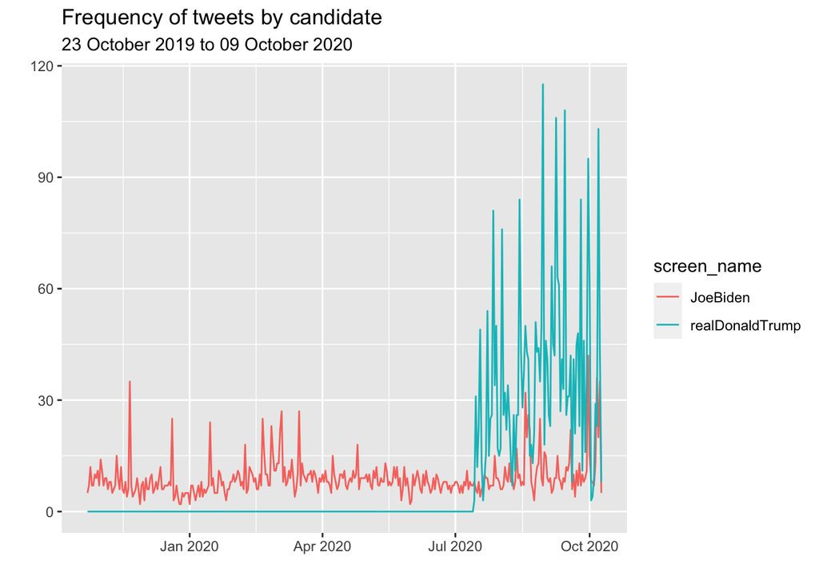

**by weeks**

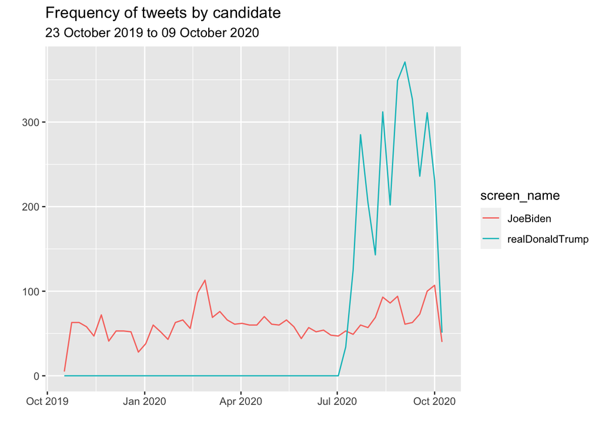

**by months (group by screen name and is_retweet)**

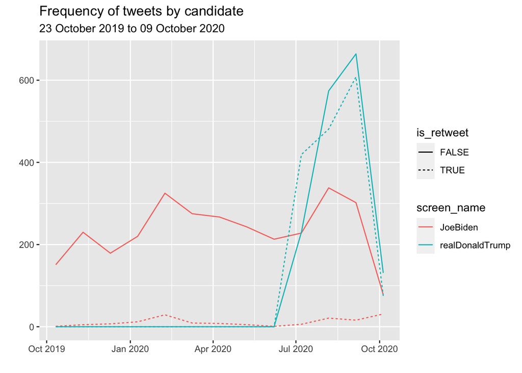

## Get number of followers for Biden and Trump

```
## # A tibble: 2 x 2
##   screen_name     followers_count
##   <chr>                     <int>
## 1 JoeBiden               10869501
## 2 realDonaldTrump        87206013
```

## Search 5000 tweets with

- the hashtag #2020Election
- exclude retweets
- save tweets to csv file

## Show summary of creation date

```
##                  Min.               1st Qu.                Median
## "2020-10-05 20:28:25" "2020-10-06 21:24:12" "2020-10-07 20:30:01"
##                  Mean               3rd Qu.                  Max.
## "2020-10-07 16:29:25" "2020-10-08 10:33:10" "2020-10-09 04:17:31"
```

## Plot hourly timeline of tweets

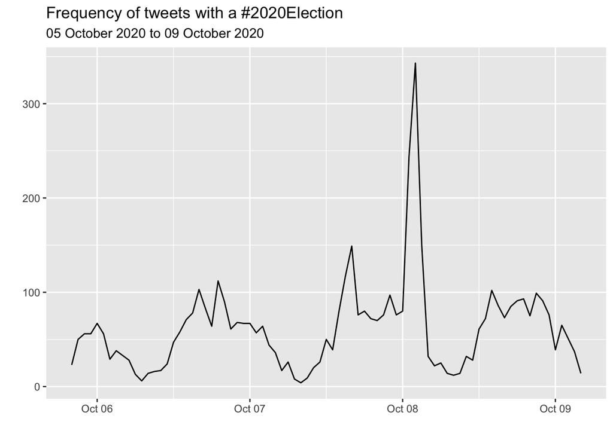

## Plot top 10 tweeting location

[figure not shown]

## Show top 10 most frequently shared link (hint: urls_expanded_url)

```
## # A tibble: 10 x 2
##    urls_expanded_url                                                           n
##    <fct>                                                                   <int>
##  1 https://thepalmierireport.com/wow-24-false-or-misleading-claims-made-b…    14
##  2 https://twitter.com/jaf_angel/status/1312256890542288898?s=19              13
##  3 https://is.gd/CM7IgS                                                       11
##  4 https://www.270towin.com/maps/consensus-2020-electoral-map-forecast        10
##  5 https://podcasts.apple.com/us/podcast/richard-helppies-common-bridge/i…    10
##  6 http://boston.gov/early-voting                                             10
##  7 https://bit.ly/32r1TgN#walkaway                                             9
##  8 https://www.270towin.com/maps/biden-trump-polling-map                       7
##  9 https://twitter.com/PatinkinMandy/status/1313441423962890242                7
## 10 https://express-press-release.net/news/2020/10/08/781630                    7
```

## Show top 3 most retweeted tweet (hint: retweet_count)

```
## # A tibble: 3 x 4
##   created_at          retweet_count screen_name   text
##   <dttm>                      <int> <chr>         <chr>
## 1 2020-10-06 00:56:14          3656 KristenClark… "🚨🚨Attn: @GovRonDeSantis &amp…
## 2 2020-10-08 10:08:42          3564 IngrahamAngle "Kamala Harris' refusal to an…
## 3 2020-10-07 03:27:28          3061 IngrahamAngle "Unmasking Biden: \n\nAfter 4…
```

## Show top 3 most favorited tweet (hint: favorite_count)

```
## # A tibble: 3 x 4
##   created_at          favorite_count screen_name   text
##   <dttm>                       <int> <chr>         <chr>
## 1 2020-10-08 10:08:42          10936 IngrahamAngle "Kamala Harris' refusal to a…
## 2 2020-10-06 00:56:14           8705 KristenClark… "🚨🚨Attn: @GovRonDeSantis &am…
## 3 2020-10-07 03:27:28           8613 IngrahamAngle "Unmasking Biden: \n\nAfter …
```

## Show top 10 tweeters

```
## # A tibble: 10 x 2
##    screen_name         n
##    <chr>           <int>
##  1 AdlerLarry         91
##  2 1989Mckoy          58
##  3 DontBHypocrites    54
##  4 miacberlanga       53
##  5 usaguyme           33
##  6 conserv_tribune    29
##  7 MediaActive        29
##  8 Bada_bing3         26
##  9 NadaLib            25
## 10 SocialPowerOne1    25
```

## What is the top tweeter saying? (In this example, it’s AdlerLarry since they tweeted the most)

- get most current 100 tweets from said user
- sort by retweet_count for display

```
## # A tibble: 20 x 2
##    created_at          text
##    <dttm>              <chr>
##  1 2020-10-09 16:05:47 "BREAKING: We need urgent calls to the House to pass the…
##  2 2020-10-09 16:10:58 "!! Larry Kudlow just now: \"The president has approved …
##  3 2020-10-09 03:17:03 "Business owners, hotels, mine workers, restaurants, air…
##  4 2020-10-09 03:18:14 "#Congress has the power to pass a bill that keeps #airl…
##  5 2020-10-09 03:16:15 "“For months, the airline industry and our labor partner…
##  6 2020-10-09 16:05:37 "My wife and I are proud aviation workers. An extension …
##  7 2020-10-09 03:31:47 "We. Need. Help. #reliefnow #getitdone @SpeakerPelosi @S…
##  8 2020-10-09 03:17:50 "🆘@SpeakerPelosi please don’t dangle my job and healthca…
##  9 2020-10-09 03:15:57 "With bipartisan support for the Aviation worker PSP, th…
## 10 2020-10-09 03:16:38 "@SenateDems @SenateGOP @HouseDemocrats @HouseGOP @senat…
## 11 2020-10-09 03:16:40 "Passing a STAND-ALONE airline relief bill will stop me,…
## 12 2020-10-09 03:17:57 "“I’m trapped in a political game of chicken where the p…
## 13 2020-10-09 03:18:53 "This is not right. This is our jobs! This is our Income…
## 14 2020-10-09 03:30:01 "It’s time to get it done. There’s bipartisan support, s…
## 15 2020-10-09 03:29:54 "@GOP @HouseGOP @SpeakerPelosi @realDonaldTrump \nJust a…
## 16 2020-10-09 03:19:31 "#ReliefNow #ExtendPSP  We need our Jobs back! Aviation …
## 17 2020-10-09 03:19:20 "We cannot wait. Flight Attendants and other essential a…
## 18 2020-10-09 16:09:54 "aviation workers are out of time. Furloughs began seven…
## 19 2020-10-09 03:18:04 "Aviation employees are 8 days without a paycheck &amp; …
## 20 2020-10-09 03:16:29 "Ladies and gentlemen please fasten your seatbelts. Poli…
```